# 2. Choosing and diagnosing spatial folds

Roozbeh Valavi

2026-09-28

## Introduction

This tutorial shows how to check whether a cross-validation design is appropriate after the folds have been created. It covers `cv_summary`, `cv_similarity`, `cv_distance`, `cv_spatial_autocor`, and `cv_block_size`.

The diagnostics answer different questions:

- `cv_summary` gives a one-call overview of fold sizes, class prevalence, environmental novelty, nearest-neighbour distances, and automatically detected warnings.
- `cv_similarity` checks whether testing folds contain novel environmental conditions relative to their training data.
- `cv_distance` checks whether the test-to-train distances in the folds resemble the distances the model will face when predicting over the target area.
- `cv_spatial_autocor` and `cv_block_size` help choose candidate spatial block sizes.

Please cite `blockCV` by: *Valavi R, Elith J, Lahoz-Monfort JJ, Guillera-Arroita G. blockCV: An R package for generating spatially or environmentally separated folds for k-fold cross-validation of species distribution models. Methods Ecol Evol. 2019; 10:225–232.* [doi: 10.1111/2041-210X.13107](https://doi.org/10.1111/2041-210X.13107)

## Prepare data and folds

Load the example presence-absence records and environmental covariates included with `blockCV`.

```r
library(blockCV)
library(sf)
library(terra)

points <- read.csv(system.file("extdata/", "species.csv", package = "blockCV"))
pa_data <- sf::st_as_sf(points, coords = c("x", "y"), crs = 7845)

rasters <- terra::rast(
  list.files(system.file("extdata/au/", package = "blockCV"), full.names = TRUE)
)
```

Create several fold designs to compare. See Tutorial 1 for a fuller explanation of the fold-creation functions.

```r
sb <- cv_spatial(x = pa_data,
                 column = "occ",
                 r = rasters,
                 k = 5,
                 size = 350000,
                 selection = "random",
                 iteration = 50,
                 progress = FALSE,
                 report = FALSE,
                 plot = FALSE)

set.seed(6)
bscv <- cv_cluster(x = pa_data,
                   column = "occ",
                   k = 5,
                   balance = TRUE,
                   k_multiplier = 3,
                   report = FALSE)

set.seed(6)
ecv <- cv_cluster(x = pa_data,
                  column = "occ",
                  r = rasters,
                  k = 5,
                  scale = TRUE)

bloo <- cv_buffer(x = pa_data,
                  column = "occ",
                  size = 350000,
                  progress = FALSE,
                  report = FALSE)

knn_blocks <- cv_knndm(x = pa_data,
                       column = "occ",
                       r = rasters,
                       k = 5,
                       clustering = "blocks",
                       keep_blocks = TRUE,
                       num_sample = 3000,
                       nk_len = 40,
                       seed = 6,
                       report = FALSE,
                       plot = FALSE)
```

## Fold-quality summary

The `cv_summary` function is the quickest way to inspect a fold design. Without a prediction domain it reports the structural summary from the `cv` object: number of folds, leave-one-out status, train/test counts, and fold warnings.

```r
summary_basic <- cv_summary(sb)
summary_basic
```

```
## blockCV fold-quality summary
## Folds: 5
##
## Fold sizes and class prevalence (train/test counts):
##   train_0 train_1 test_0 test_1
## 1     211     210     46     33
## 2     186     202     71     41
## 3     203     182     54     61
## 4     220     205     37     38
## 5     208     173     49     70
##
## Warnings:
##   none
```

When `r`, `pred_points`, or `model_domain` is supplied, `cv_summary` also adds the distance diagnostic. When `r` is supplied, it also adds the environmental novelty diagnostic. These are the same data-oriented computations used by `cv_distance` and `cv_similarity`.

```r
summary_full <- cv_summary(cv = sb,
                           x = pa_data,
                           r = rasters,
                           num_sample = 3000,
                           seed = 6,
                           progress = FALSE)

summary_full$distances
```

```
##   fold n_test   min    q1 median     q3    max pct_below_pred
## 1    1     79  8558 90160 134000 176000 258700           98.7
## 2    2    112  8558 76910 112900 159200 285600           98.2
## 3    3    115 12100 66010 104100 154200 311500           95.7
## 4    4     75  8558 56290 107200 175400 537200           82.7
## 5    5    119  8558 77020 108300 145700 367500           86.6
```

```r
summary_full$novelty
```

```
##   fold n_test pct_novel    min median limiting_var
## 1    1     79       1.3 -11.33  18.53       bio_12
## 2    2    112      11.6  -7.02   4.64        bio_4
## 3    3    115       3.5  -5.15  12.99       bio_15
## 4    4     75       0.0   0.94  27.29         <NA>
## 5    5    119       2.5  -0.84  30.45       bio_12
```

```r
summary_full$warnings
```

```
##   fold         type
## 1    1 high_leakage
## 2    2 high_leakage
## 3    3 high_leakage
##                                                                                          message
## 1 99% of test points nearer to train than the median prediction distance (optimistic/leaky fold)
## 2 98% of test points nearer to train than the median prediction distance (optimistic/leaky fold)
## 3 96% of test points nearer to train than the median prediction distance (optimistic/leaky fold)
```

The warnings are returned as data, not as R warning conditions, so they can be filtered or saved in an analysis pipeline. For k-fold designs they can flag empty or tiny test folds, single-class test folds, classes missing from training, severe imbalance, and high leakage. For leave-one-out designs such as `cv_buffer` and `cv_nndm`, structural fold-size warnings are skipped because each fold holds a single test point by design.

## Environmental similarity diagnostics

The `cv_similarity` function evaluates environmental similarity between training and testing folds. It supports `method = "MESS"`, `method = "L1"`, and `method = "L2"`. Negative values indicate environmental novelty: at least one testing point is less similar to its fold’s training data than the selected method’s reference.

The function returns a `cv_similarity` object. The plot is stored in `$plot`, the per-fold table in `$extrapolation`, and the overall novelty rate in `$overall`. Set `plot = FALSE` when you want to save or customise the plot object instead of drawing it immediately.

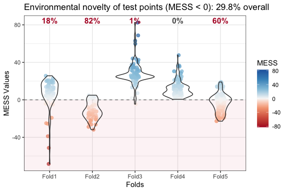

```r
sim <- cv_similarity(cv = ecv,
                     x = pa_data,
                     r = rasters,
                     method = "MESS",
                     plot = FALSE,
                     progress = FALSE)

sim$plot
```

```r
sim$extrapolation
```

```
##   fold n_test pct_novel    min median limiting_var
## 1    1     79      17.7 -68.43   9.98       bio_12
## 2    2     51      82.4 -31.91 -12.88        bio_4
## 3    3     78       1.3  -4.64  25.12        bio_5
## 4    4    139       0.0   0.55   9.42         <NA>
## 5    5    153      60.1 -22.82  -1.83        bio_4
```

```r
sim$overall
```

```
## [1] 29.8
```

Setting `type = "map"` shows where extrapolation occurs in geographical space. Testing points are coloured by their similarity value (here MESS), so novel points are easy to locate.

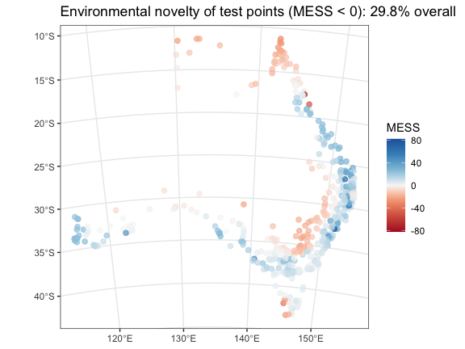

```r
cv_similarity(cv = ecv,
              x = pa_data,
              r = rasters,
              method = "MESS",
              type = "map",
              plot = TRUE,
              progress = FALSE)
```

The distance-based `L1` and `L2` scores use a random raster sample as their baseline, so set `seed` when reproducibility matters. Use `num_plots` to show a subset of folds.

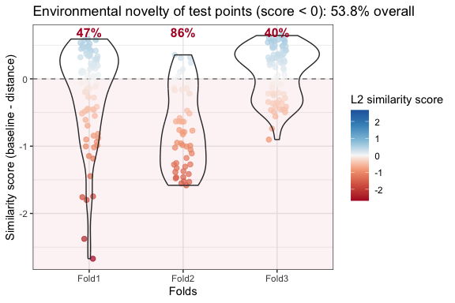

```r
cv_similarity(cv = ecv,
              x = pa_data,
              r = rasters,
              method = "L2",
              num_plots = 1:3,
              num_sample = 3000,
              seed = 6,
              plot = TRUE,
              progress = FALSE)
```

## Nearest-neighbour distance diagnostics

The `cv_distance` function compares the nearest-neighbour distance distribution of a fold design with the distance distribution expected across the prediction domain. It returns a `cv_distance` object with the plot in `$plot`, per-fold distance summaries in `$distances`, and Wasserstein-1 distances in `$W`. Lower Wasserstein-1 values indicate a closer match to the prediction domain.

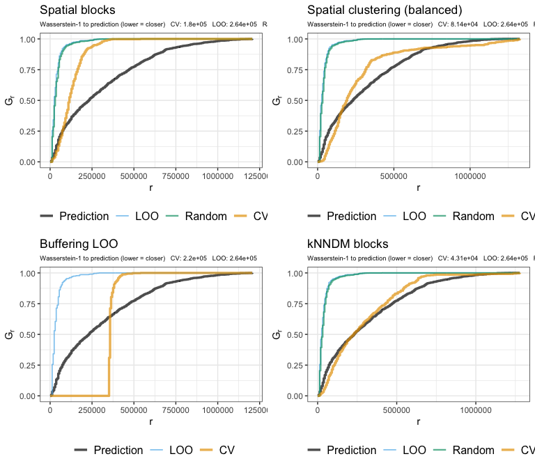

```r
distance_theme <- ggplot2::theme(
  legend.position = "bottom",
  plot.subtitle = ggplot2::element_text(size = 7)
)

dist_sb <- cv_distance(cv = sb,
                       x = pa_data,
                       r = rasters,
                       num_sample = 3000,
                       num_random = 5,
                       seed = 6,
                       plot = FALSE)

dist_bscv <- cv_distance(cv = bscv,
                         x = pa_data,
                         r = rasters,
                         num_sample = 3000,
                         num_random = 5,
                         seed = 6,
                         plot = FALSE)

dist_bloo <- cv_distance(cv = bloo,
                         x = pa_data,
                         r = rasters,
                         add_random = FALSE,
                         num_sample = 3000,
                         seed = 6,
                         plot = FALSE)

dist_knn <- cv_distance(cv = knn_blocks,
                        x = pa_data,
                        r = rasters,
                        num_sample = 3000,
                        num_random = 5,
                        seed = 6,
                        plot = FALSE)

cowplot::plot_grid(
  dist_sb$plot +
    ggplot2::labs(title = "Spatial blocks") +
    distance_theme,
  dist_bscv$plot +
    ggplot2::labs(title = "Spatial clustering (balanced)") +
    distance_theme,
  dist_bloo$plot +
    ggplot2::labs(title = "Buffering LOO") +
    distance_theme,
  dist_knn$plot +
    ggplot2::labs(title = "kNNDM blocks") +
    distance_theme,
  ncol = 2
)
```

The `W` vector summarises the area between each curve and the prediction curve. The `distances` table shows the spread of test-to-nearest-train distances within each fold. The `pct_below_pred` column reports the percentage of test points that are closer to training data than the median prediction distance; high values indicate folds that may be easier than the prediction task.

```r
dist_sb$W
```

```
##       CV      LOO   Random
## 179895.2 263821.6 259662.7
```

```r
dist_sb$distances
```

```
##   fold n_test   min    q1 median     q3    max pct_below_pred
## 1    1     79  8558 90160 134000 176000 258700           98.7
## 2    2    112  8558 76910 112900 159200 285600           98.2
## 3    3    115 12100 66010 104100 154200 311500           95.7
## 4    4     75  8558 56290 107200 175400 537200           82.7
## 5    5    119  8558 77020 108300 145700 367500           86.6
```

Distances are geographical by default. Set `space = "feature"` to compute distances in the covariate space of `r`, optionally scaled with `scale = TRUE`.

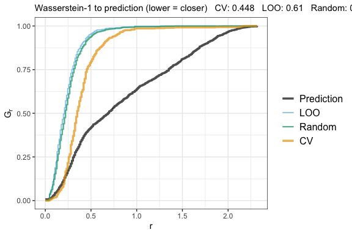

```r
dist_feature <- cv_distance(cv = sb,
                            x = pa_data,
                            r = rasters,
                            space = "feature",
                            num_sample = 3000,
                            seed = 6,
                            plot = FALSE)

dist_feature$plot
```

## Choosing a candidate block size

To support a first choice of block size before model fitting, `cv_spatial_autocor` estimates the effective range of spatial autocorrelation in the response or continuous predictor rasters. This tool is a guide, not an absolute rule.

Roberts et al. (2017) recommend choosing spatial blocks with reference to the autocorrelation range of model residuals. The response and predictor variograms shown here are useful exploratory guides before a model has been fitted, but they are not residual autocorrelation ranges and can under- or over-estimate the block size needed for residual-based guidance. To estimate residual autocorrelation with `cv_spatial_autocor`, fit the model first, add the residuals as a column in the sample points object, and pass that column name to `column`.

When only `r` is supplied, the function fits variograms to the continuous raster covariates and reports the median range.

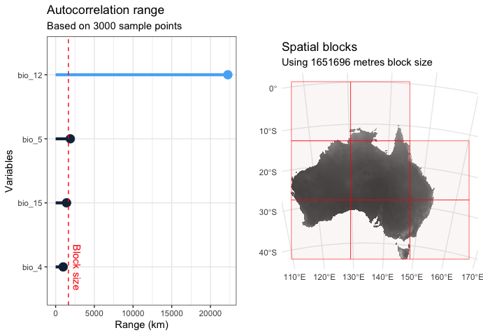

```r
sac_raster <- cv_spatial_autocor(r = rasters,
                                 num_sample = 3000,
                                 progress = FALSE,
                                 plot = FALSE)

plot(sac_raster)
```

```r
sac_raster$range
```

```
## [1] 1651696
```

```r
summary(sac_raster)
```

```
## Summary statistics of spatial autocorrelation ranges of all input layers:
##     Min.  1st Qu.   Median     Mean  3rd Qu.     Max.
##   972128  1300689  1651696  6631027  6982034 22248586
##   layers      range
## 3  bio_4   972128.3
## 2 bio_15  1410209.4
## 4  bio_5  1893182.7
## 1 bio_12 22248586.3
```

Alternatively, supply the sample points and a response, count, continuous, or residual column.

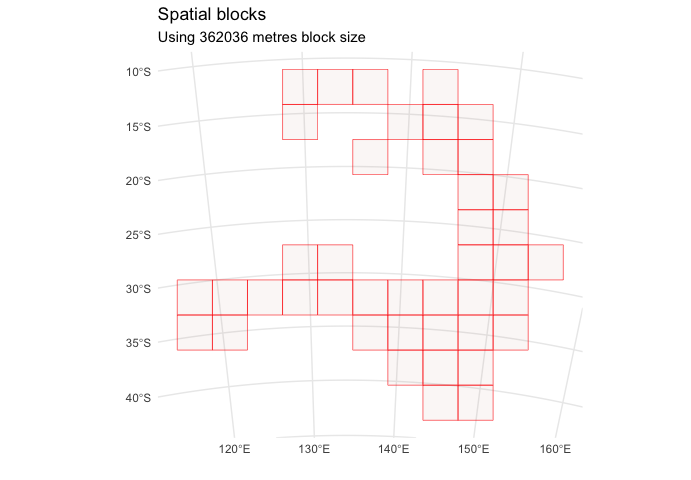

```r
sac_points <- cv_spatial_autocor(x = pa_data,
                                 column = "occ",
                                 plot = FALSE)

plot(sac_points)
```

`cv_block_size` provides an interactive Shiny app for manually exploring spatial block sizes. The app cannot be shown inside the vignette because it requires an interactive R session.

```r
cv_block_size(x = pa_data,
              column = "occ",
              r = rasters,
              min_size = 2e5,
              max_size = 9e5)
```

## References:

- Elith, J., Kearney, M., & Phillips, S. (2010) The art of modelling range-shifting species. Methods in Ecology and Evolution, 1(4), 330-342.
- Hiemstra, P. H., Pebesma, E. J., Twenhöfel, C. J., & Heuvelink, G. B. (2009) Real-time automatic interpolation of ambient gamma dose rates from the Dutch radioactivity monitoring network. Computers & Geosciences, 35(8), 1711-1721.
- Linnenbrink, J., Milà, C., Ludwig, M., & Meyer, H. (2024) kNNDM CV: k-fold nearest neighbour distance matching cross-validation for map accuracy estimation. Geoscientific Model Development, 17(15), 5897-5912. [doi: 10.5194/gmd-17-5897-2024](https://doi.org/10.5194/gmd-17-5897-2024)
- Milà, C., Mateu, J., Pebesma, E., & Meyer, H. (2022) Nearest neighbour distance matching leave-one-out cross-validation for map validation. Methods in Ecology and Evolution, 13(6), 1304-1316.
- O’Sullivan, D., & Unwin, D. J. (2010) Geographic Information Analysis (2nd ed.). John Wiley & Sons.
- Roberts, D. R., Bahn, V., Ciuti, S., Boyce, M. S., Elith, J., Guillera-Arroita, G., Hauenstein, S., Lahoz-Monfort, J. J., Schroeder, B., Thuiller, W., Warton, D. I., Wintle, B. A., Hartig, F., & Dormann, C. F. (2017) Cross-validation strategies for data with temporal, spatial, hierarchical, or phylogenetic structure. Ecography, 40, 913-929.
- Valavi R, Elith J, Lahoz-Monfort JJ, Guillera-Arroita G. (2019) **blockCV: An R package for generating spatially or environmentally separated folds for k-fold cross-validation of species distribution models**. *Methods Ecol Evol.* 10:225-232. [doi: 10.1111/2041-210X.13107](https://doi.org/10.1111/2041-210X.13107)